# Project: Investigate a Dataset - NICS and Census data

- Introduction
- Data Wrangling
- Exploratory Data Analysis
- Conclusions

## Introduction

### Dataset Description

The datasets analyzed in this project consist of the following information:

1. 1998-2017 National Instant Criminal Background Check System (NICS) Data: Data related to the number of background checks completed for requests to apply for the right to have a gun ownership permit in each state, permit renewals, and specific types of gun transactions for each of the 50 U.S. states. This project will specifically focus on background check data regarding only gun-type transactions from 2016.
2. 2010-2016 U.S. Census Data: Demographic data for each U.S. state census collection efforts regarding population information such as overall density, demographic breakdowns by age, race, gender, income and many other items. This project will specifically focus on the available census demographic data regarding race, gender and population density from 2016.

#### Dataset Columns and Relationships

**NICS Dataset**:

'month', 'state', 'permit', 'permit_recheck', 'handgun', 'long_gun', 'other', 'multiple', 'admin', 'prepawn_handgun', 'prepawn_long_gun', 'prepawn_other', 'redemption_handgun', 'redemption_long_gun', 'redemption_other', 'returned_handgun', 'returned_long_gun', 'returned_other', 'rentals_handgun', 'rentals_long_gun', 'private_sale_handgun', 'private_sale_long_gun', 'private_sale_other', 'return_to_seller_handgun', 'return_to_seller_long_gun', 'return_to_seller_other', 'totals'

These columns are significant in that they provide us the number of background checks need to formulate the dependent variable (i.e., number of checks per capita) for analysis of the question and hypothesis highlighted below. This project will use the handgun, long_gun, other, and multiple columns to determine if mutliple demographic factors from the Census dataset affect the number of background investigations initiated throughout the U.S. when gun transactions occur. The permit information will not be used in this project.

**Census Dataset**: 'Fact', 'Fact Note', 'Alabama', 'Alaska', 'Arizona', 'Arkansas', 'California', 'Colorado', 'Connecticut', 'Delaware', 'Florida', 'Georgia', 'Hawaii', 'Idaho', 'Illinois', 'Indiana', 'Iowa', 'Kansas', 'Kentucky', 'Louisiana', 'Maine', 'Maryland', 'Massachusetts', 'Michigan', 'Minnesota', 'Mississippi', 'Missouri', 'Montana', 'Nebraska', 'Nevada', 'New Hampshire', 'New Jersey', 'New Mexico', 'New York', 'North Carolina', 'North Dakota', 'Ohio', 'Oklahoma', 'Oregon', 'Pennsylvania', 'Rhode Island', 'South Carolina', 'South Dakota', 'Tennessee', 'Texas', 'Utah', 'Vermont', 'Virginia', 'Washington', 'West Virginia', 'Wisconsin', 'Wyoming'

While the columns in this initial dataset are important (they separate the data by state for analysis), it is the data regarding each state that is of more signficance. The data will be transposed to highlight this fact and allow comparisons. The individual rows identify the specific demographics that will be used to compare and contrast any correlation between the number of backgrounds checked conducted in each state for gun transactions and the demographics that could impact whether or not background checks are initiatied. The data will be rearranged to match the NICS data.

### Question(s) for Analysis

The overall question this project will address is:

*What is the relationship between state demographics (population density, gender, and race) and the rate of firearm background checks per capita in the U.S. during 2016?*

#### Hypotheses

1. States with higher population densities will have more firearm background check rates per capita.
2. Gender composition of the population will not have a significant relationship with firearm background check rates.
3. Racial composition will show an overall weak, or no, association to firearm background check rates.

```python
import pandas as pd
import numpy as np
import matplotlib.pyplot as plt
```

## Data Wrangling

### General Properties

```python
# Reading in table data for project datasets
df_gun = pd.read_csv("Database_Nics_and_Census_data/gun_data.csv")
df_census = pd.read_csv("Database_Nics_and_Census_data/US_Census_Data.csv")
```

```python
# Gun dataframe shape and overall table format/information
print("Gun data shape: ", df_gun.shape, "\n")
print(df_gun.head())
```

```
Gun data shape:  (12485, 27)

     month       state   permit  permit_recheck  handgun  long_gun   other  \
0  2017-09     Alabama  16717.0             0.0   5734.0    6320.0   221.0
1  2017-09      Alaska    209.0             2.0   2320.0    2930.0   219.0
2  2017-09     Arizona   5069.0           382.0  11063.0    7946.0   920.0
3  2017-09    Arkansas   2935.0           632.0   4347.0    6063.0   165.0
4  2017-09  California  57839.0             0.0  37165.0   24581.0  2984.0

   multiple  admin  prepawn_handgun  ...  returned_other  rentals_handgun  \
0       317    0.0             15.0  ...             0.0              0.0
1       160    0.0              5.0  ...             0.0              0.0
2       631    0.0             13.0  ...             0.0              0.0
3       366   51.0             12.0  ...             0.0              0.0
4         0    0.0              0.0  ...             0.0              0.0

   rentals_long_gun  private_sale_handgun  private_sale_long_gun  \
0               0.0                   9.0                   16.0
1               0.0                  17.0                   24.0
2               0.0                  38.0                   12.0
3               0.0                  13.0                   23.0
4               0.0                   0.0                    0.0

   private_sale_other  return_to_seller_handgun  return_to_seller_long_gun  \
0                 3.0                       0.0                        0.0
1                 1.0                       0.0                        0.0
2                 2.0                       0.0                        0.0
3                 0.0                       0.0                        2.0
4                 0.0                       0.0                        0.0

   return_to_seller_other  totals
0                     3.0   32019
1                     0.0    6303
2                     0.0   28394
3                     1.0   17747
4                     0.0  123506

[5 rows x 27 columns]
```

```python
# Retrieve column names and types to determine any cleaning needs
df_gun.dtypes
```

```
month                         object
state                         object
permit                       float64
permit_recheck               float64
handgun                      float64
long_gun                     float64
other                        float64
multiple                       int64
admin                        float64
prepawn_handgun              float64
prepawn_long_gun             float64
prepawn_other                float64
redemption_handgun           float64
redemption_long_gun          float64
redemption_other             float64
returned_handgun             float64
returned_long_gun            float64
returned_other               float64
rentals_handgun              float64
rentals_long_gun             float64
private_sale_handgun         float64
private_sale_long_gun        float64
private_sale_other           float64
return_to_seller_handgun     float64
return_to_seller_long_gun    float64
return_to_seller_other       float64
totals                         int64
dtype: object
```

```python
# Create new dataframe to aggregate data for 2016-only analysis and remove unnecessary fields such as permit/admin/total checks
df_gun_copy = df_gun[df_gun['month'].str.contains('2016')]
df_gun_copy = df_gun_copy.groupby(['state']).sum(numeric_only=True)
df_gun_2016 = df_gun_copy.drop(['permit', 'permit_recheck', 'admin', 'totals'], axis=1)
df_gun_2016['total_checks'] = df_gun_2016.sum(axis=1)
df_gun_2016.head()
```

| state | handgun | long_gun | other | multiple | prepawn_handgun | prepawn_long_gun | prepawn_other | redemption_handgun | redemption_long_gun | redemption_other | ... | returned_other | rentals_handgun | rentals_long_gun | private_sale_handgun | private_sale_long_gun | private_sale_other | return_to_seller_handgun | return_to_seller_long_gun | return_to_seller_other | total_checks |
| --- | --- | --- | --- | --- | --- | --- | --- | --- | --- | --- | --- | --- | --- | --- | --- | --- | --- | --- | --- | --- | --- |
| Alabama | 153123.0 | 121963.0 | 6104.0 | 6545 | 111.0 | 114.0 | 2.0 | 20036.0 | 17697.0 | 62.0 | ... | 0.0 | 0.0 | 0.0 | 72.0 | 65.0 | 4.0 | 3.0 | 2.0 | 0.0 | 325903.0 |
| Alaska | 37491.0 | 36887.0 | 2889.0 | 2316 | 84.0 | 70.0 | 0.0 | 2234.0 | 2046.0 | 24.0 | ... | 0.0 | 0.0 | 0.0 | 39.0 | 66.0 | 1.0 | 2.0 | 3.0 | 0.0 | 84526.0 |
| Arizona | 166784.0 | 108988.0 | 13122.0 | 7908 | 74.0 | 60.0 | 3.0 | 16576.0 | 8390.0 | 78.0 | ... | 1.0 | 0.0 | 0.0 | 76.0 | 56.0 | 11.0 | 11.0 | 11.0 | 1.0 | 323399.0 |
| Arkansas | 80244.0 | 82120.0 | 3059.0 | 4400 | 77.0 | 116.0 | 3.0 | 12645.0 | 20532.0 | 29.0 | ... | 0.0 | 0.0 | 0.0 | 72.0 | 64.0 | 6.0 | 7.0 | 4.0 | 1.0 | 203379.0 |
| California | 560355.0 | 554550.0 | 211707.0 | 0 | 0.0 | 0.0 | 0.0 | 6752.0 | 6645.0 | 177.0 | ... | 0.0 | 0.0 | 0.0 | 0.0 | 0.0 | 0.0 | 0.0 | 0.0 | 0.0 | 1340186.0 |

5 rows × 22 columns

#### NICS Data Wrangling Steps

The firearms background check data was retrieved using standard Pandas dataframe reading techniques. Following that, the initial dataset was reviewed through the shape property and head method to determine the overall data being dealt with. This shows us that, before working with 2016 data, there were over 12,000 rows for all years involved. This is in addition to 27 columns containing mostly float types, as is common for fields with "NA" data.

In order to properly clean and analyze only relevant information alongside the census data, a new dataframe of only 2016 information was created. The data was grouped by state, and all numbers summed, to ensure we have proper, annual aggregation to compare to the census data. We have removed the permit and permit_check fields which are unnecessary for this project, as well as could cause confusion on final analysis as different states have different permit requirements that would not be accurately captured.

This leaves us with the following final columns that will be used a the dependent variables of the background check numbers:

- 'handgun', 'long_gun', 'other', 'multiple', 'prepawn_handgun','prepawn_long_gun', 'prepawn_other', 'redemption_handgun', 'redemption_long_gun', 'redemption_other', 'returned_handgun', 'returned_long_gun', 'returned_other', 'rentals_handgun', 'rentals_long_gun', 'private_sale_handgun', 'private_sale_long_gun', 'private_sale_other', 'return_to_seller_handgun', 'return_to_seller_long_gun', 'return_to_seller_other', 'total_checks'

```python
# Census dataframe shape and overall table format/information
print("Census data shape: ", df_census.shape, "\n")
df_census.head()
```

```
Census data shape:  (85, 52)
```

|  | Fact | Fact Note | Alabama | Alaska | Arizona | Arkansas | California | Colorado | Connecticut | Delaware | ... | South Dakota | Tennessee | Texas | Utah | Vermont | Virginia | Washington | West Virginia | Wisconsin | Wyoming |
| --- | --- | --- | --- | --- | --- | --- | --- | --- | --- | --- | --- | --- | --- | --- | --- | --- | --- | --- | --- | --- | --- |
| 0 | Population estimates, July 1, 2016, (V2016) | NaN | 4,863,300 | 741,894 | 6,931,071 | 2,988,248 | 39,250,017 | 5,540,545 | 3,576,452 | 952,065 | ... | 865454 | 6651194 | 27,862,596 | 3,051,217 | 624,594 | 8,411,808 | 7,288,000 | 1,831,102 | 5,778,708 | 585,501 |
| 1 | Population estimates base, April 1, 2010, (V2... | NaN | 4,780,131 | 710,249 | 6,392,301 | 2,916,025 | 37,254,522 | 5,029,324 | 3,574,114 | 897,936 | ... | 814195 | 6346298 | 25,146,100 | 2,763,888 | 625,741 | 8,001,041 | 6,724,545 | 1,853,011 | 5,687,289 | 563,767 |
| 2 | Population, percent change - April 1, 2010 (es... | NaN | 1.70% | 4.50% | 8.40% | 2.50% | 5.40% | 10.20% | 0.10% | 6.00% | ... | 0.063 | 0.048 | 10.80% | 10.40% | -0.20% | 5.10% | 8.40% | -1.20% | 1.60% | 3.90% |
| 3 | Population, Census, April 1, 2010 | NaN | 4,779,736 | 710,231 | 6,392,017 | 2,915,918 | 37,253,956 | 5,029,196 | 3,574,097 | 897,934 | ... | 814180 | 6346105 | 25,145,561 | 2,763,885 | 625,741 | 8,001,024 | 6,724,540 | 1,852,994 | 5,686,986 | 563,626 |
| 4 | Persons under 5 years, percent, July 1, 2016, ... | NaN | 6.00% | 7.30% | 6.30% | 6.40% | 6.30% | 6.10% | 5.20% | 5.80% | ... | 0.071 | 0.061 | 7.20% | 8.30% | 4.90% | 6.10% | 6.20% | 5.50% | 5.80% | 6.50% |

5 rows × 52 columns

```python
# Create new dataframe to aggregate data for 2016-only analysis
# by transposing state columns to rows to match background check data
df_census_transposed = df_census.transpose()
new_headers = df_census_transposed.iloc[0]
df_census_transposed.columns = new_headers
df_census_2016 = df_census_transposed[2:]
df_census_2016.head()
```

| Fact | Population estimates, July 1, 2016, (V2016) | Population estimates base, April 1, 2010, (V2016) | Population, percent change - April 1, 2010 (estimates base) to July 1, 2016, (V2016) | Population, Census, April 1, 2010 | Persons under 5 years, percent, July 1, 2016, (V2016) | Persons under 5 years, percent, April 1, 2010 | Persons under 18 years, percent, July 1, 2016, (V2016) | Persons under 18 years, percent, April 1, 2010 | Persons 65 years and over, percent, July 1, 2016, (V2016) | Persons 65 years and over, percent, April 1, 2010 | ... | NaN | Value Flags | - | D | F | FN | NaN | S | X | Z |
| --- | --- | --- | --- | --- | --- | --- | --- | --- | --- | --- | --- | --- | --- | --- | --- | --- | --- | --- | --- | --- | --- |
| Alabama | 4,863,300 | 4,780,131 | 1.70% | 4,779,736 | 6.00% | 6.40% | 22.60% | 23.70% | 16.10% | 13.80% | ... | NaN | NaN | NaN | NaN | NaN | NaN | NaN | NaN | NaN | NaN |
| Alaska | 741,894 | 710,249 | 4.50% | 710,231 | 7.30% | 7.60% | 25.20% | 26.40% | 10.40% | 7.70% | ... | NaN | NaN | NaN | NaN | NaN | NaN | NaN | NaN | NaN | NaN |
| Arizona | 6,931,071 | 6,392,301 | 8.40% | 6,392,017 | 6.30% | 7.10% | 23.50% | 25.50% | 16.90% | 13.80% | ... | NaN | NaN | NaN | NaN | NaN | NaN | NaN | NaN | NaN | NaN |
| Arkansas | 2,988,248 | 2,916,025 | 2.50% | 2,915,918 | 6.40% | 6.80% | 23.60% | 24.40% | 16.30% | 14.40% | ... | NaN | NaN | NaN | NaN | NaN | NaN | NaN | NaN | NaN | NaN |
| California | 39,250,017 | 37,254,522 | 5.40% | 37,253,956 | 6.30% | 6.80% | 23.20% | 25.00% | 13.60% | 11.40% | ... | NaN | NaN | NaN | NaN | NaN | NaN | NaN | NaN | NaN | NaN |

5 rows × 85 columns

```python
# Verify the actual columns in the dataset which are not shown above
df_census_2016.columns
```

```
Index([                                          'Population estimates, July 1, 2016,  (V2016)',
                                           'Population estimates base, April 1, 2010,  (V2016)',
        'Population, percent change - April 1, 2010 (estimates base) to July 1, 2016,  (V2016)',
                                                            'Population, Census, April 1, 2010',
                                       'Persons under 5 years, percent, July 1, 2016,  (V2016)',
                                                'Persons under 5 years, percent, April 1, 2010',
                                      'Persons under 18 years, percent, July 1, 2016,  (V2016)',
                                               'Persons under 18 years, percent, April 1, 2010',
                                  'Persons 65 years and over, percent,  July 1, 2016,  (V2016)',
                                            'Persons 65 years and over, percent, April 1, 2010',
                                             'Female persons, percent,  July 1, 2016,  (V2016)',
                                                       'Female persons, percent, April 1, 2010',
                                                 'White alone, percent, July 1, 2016,  (V2016)',
                             'Black or African American alone, percent, July 1, 2016,  (V2016)',
                     'American Indian and Alaska Native alone, percent, July 1, 2016,  (V2016)',
                                                 'Asian alone, percent, July 1, 2016,  (V2016)',
            'Native Hawaiian and Other Pacific Islander alone, percent, July 1, 2016,  (V2016)',
                                           'Two or More Races, percent, July 1, 2016,  (V2016)',
                                          'Hispanic or Latino, percent, July 1, 2016,  (V2016)',
                         'White alone, not Hispanic or Latino, percent, July 1, 2016,  (V2016)',
                                                                          'Veterans, 2011-2015',
                                                     'Foreign born persons, percent, 2011-2015',
                                                       'Housing units,  July 1, 2016,  (V2016)',
                                                                 'Housing units, April 1, 2010',
                                                  'Owner-occupied housing unit rate, 2011-2015',
                                      'Median value of owner-occupied housing units, 2011-2015',
                              'Median selected monthly owner costs -with a mortgage, 2011-2015',
                           'Median selected monthly owner costs -without a mortgage, 2011-2015',
                                                                 'Median gross rent, 2011-2015',
                                                                       'Building permits, 2016',
                                                                        'Households, 2011-2015',
                                                             'Persons per household, 2011-2015',
                   'Living in same house 1 year ago, percent of persons age 1 year+, 2011-2015',
       'Language other than English spoken at home, percent of persons age 5 years+, 2011-2015',
                  'High school graduate or higher, percent of persons age 25 years+, 2011-2015',
                     'Bachelor's degree or higher, percent of persons age 25 years+, 2011-2015',
                                    'With a disability, under age 65 years, percent, 2011-2015',
                               'Persons  without health insurance, under age 65 years, percent',
               'In civilian labor force, total, percent of population age 16 years+, 2011-2015',
              'In civilian labor force, female, percent of population age 16 years+, 2011-2015',
```

[output cut: 31 more lines]

```
                                                                                   'Fact Notes',
                                                                                          '(a)',
                                                                                          '(b)',
                                                                                          '(c)',
                                                                                            nan,
                                                                                  'Value Flags',
                                                                                            '-',
                                                                                            'D',
                                                                                            'F',
                                                                                           'FN',
                                                                                            nan,
                                                                                            'S',
                                                                                            'X',
                                                                                            'Z'],
      dtype='object', name='Fact')
```

```python
# Create new dataframe for 2016 only census data consisting of the appropriate independent variables, per state, on population,
# gender, and race data. Final column names and types are determined and will require updating before cleaning and analysis.
census_cols = [
    'Population estimates, July 1, 2016,  (V2016)',
    'Land area in square miles, 2010',
    'Female persons, percent,  July 1, 2016,  (V2016)',
    'White alone, percent, July 1, 2016,  (V2016)',
    'Black or African American alone, percent, July 1, 2016,  (V2016)',
    'American Indian and Alaska Native alone, percent, July 1, 2016,  (V2016)',
    'Asian alone, percent, July 1, 2016,  (V2016)',
    'Native Hawaiian and Other Pacific Islander alone, percent, July 1, 2016,  (V2016)',
    'Two or More Races, percent, July 1, 2016,  (V2016)'
]
df_census_2016_work = df_census_2016[census_cols].copy()
df_census_2016_work.head()
```

| Fact | Population estimates, July 1, 2016, (V2016) | Land area in square miles, 2010 | Female persons, percent, July 1, 2016, (V2016) | White alone, percent, July 1, 2016, (V2016) | Black or African American alone, percent, July 1, 2016, (V2016) | American Indian and Alaska Native alone, percent, July 1, 2016, (V2016) | Asian alone, percent, July 1, 2016, (V2016) | Native Hawaiian and Other Pacific Islander alone, percent, July 1, 2016, (V2016) | Two or More Races, percent, July 1, 2016, (V2016) |
| --- | --- | --- | --- | --- | --- | --- | --- | --- | --- |
| Alabama | 4,863,300 | 50,645.33 | 51.60% | 69.30% | 26.80% | 0.70% | 1.40% | 0.10% | 1.60% |
| Alaska | 741,894 | 570,640.95 | 47.70% | 66.10% | 3.80% | 15.20% | 6.30% | 1.30% | 7.30% |
| Arizona | 6,931,071 | 113,594.08 | 50.30% | 83.30% | 4.90% | 5.40% | 3.40% | 0.30% | 2.80% |
| Arkansas | 2,988,248 | 52,035.48 | 50.90% | 79.40% | 15.70% | 1.00% | 1.60% | 0.30% | 2.00% |
| California | 39,250,017 | 155,779.22 | 50.30% | 72.70% | 6.50% | 1.70% | 14.80% | 0.50% | 3.80% |

```python
# Review the current data types to determine if any conversions are needed such as strings to numeric values for cleaning
# and analysis
df_census_2016_work.dtypes
```

```
Fact
Population estimates, July 1, 2016,  (V2016)                                         object
Land area in square miles, 2010                                                      object
Female persons, percent,  July 1, 2016,  (V2016)                                     object
White alone, percent, July 1, 2016,  (V2016)                                         object
Black or African American alone, percent, July 1, 2016,  (V2016)                     object
American Indian and Alaska Native alone, percent, July 1, 2016,  (V2016)             object
Asian alone, percent, July 1, 2016,  (V2016)                                         object
Native Hawaiian and Other Pacific Islander alone, percent, July 1, 2016,  (V2016)    object
Two or More Races, percent, July 1, 2016,  (V2016)                                   object
dtype: object
```

```python
# Rename columns for easier functional references when cleaning later and to match the formatting of the gun dataframe
col_formatted = {
    'Population estimates, July 1, 2016,  (V2016)': 'population_2016',
    'Land area in square miles, 2010': 'land_area_sqmi_2010',
    'Female persons, percent,  July 1, 2016,  (V2016)': 'female_percent_2016',
    'White alone, percent, July 1, 2016,  (V2016)': 'white_percent_2016',
    'Black or African American alone, percent, July 1, 2016,  (V2016)': 'black_percent_2016',
    'American Indian and Alaska Native alone, percent, July 1, 2016,  (V2016)': 'ai_an_percent_2016',
    'Asian alone, percent, July 1, 2016,  (V2016)': 'asian_percent_2016',
    'Native Hawaiian and Other Pacific Islander alone, percent, July 1, 2016,  (V2016)': 'pi_percent_2016',
    'Two or More Races, percent, July 1, 2016,  (V2016)': 'two_or_more_percent_2016'
}
df_census_2016_work = df_census_2016_work.rename(columns=col_formatted)
df_census_2016_work.head()
```

| Fact | population_2016 | land_area_sqmi_2010 | female_percent_2016 | white_percent_2016 | black_percent_2016 | ai_an_percent_2016 | asian_percent_2016 | pi_percent_2016 | two_or_more_percent_2016 |
| --- | --- | --- | --- | --- | --- | --- | --- | --- | --- |
| Alabama | 4,863,300 | 50,645.33 | 51.60% | 69.30% | 26.80% | 0.70% | 1.40% | 0.10% | 1.60% |
| Alaska | 741,894 | 570,640.95 | 47.70% | 66.10% | 3.80% | 15.20% | 6.30% | 1.30% | 7.30% |
| Arizona | 6,931,071 | 113,594.08 | 50.30% | 83.30% | 4.90% | 5.40% | 3.40% | 0.30% | 2.80% |
| Arkansas | 2,988,248 | 52,035.48 | 50.90% | 79.40% | 15.70% | 1.00% | 1.60% | 0.30% | 2.00% |
| California | 39,250,017 | 155,779.22 | 50.30% | 72.70% | 6.50% | 1.70% | 14.80% | 0.50% | 3.80% |

### Census Data Wrangling Steps

Similar to the NICS dataset, the initial census dataset was reviewed through the shape property and head method to determine the overall data being dealt with. To ensure only appropriate data is used & compared for analysis to answer the project questions, the columns and rows were transposed so the census index matches the state indexes of the gun dataset.

Following the transposition, and again to ensure only applicable data is reviewed and merged in following steps, the data was reduced to the following columns:

- population_2016 for population analysis
- land_area_sqmi_2010 to be used in connection with the population to determine per capita estimates from the year at issue
- female_2016_percent to review the gender differences
- racial percentage breakdown columns to review racial differences

```python
# To finalize wrangling, the tables will be combined into a finalized dataset for cleaning and overall analysis
# First, index differences will be removed
df_gun_2016.index.difference(df_census_2016.index)
```

```
Index(['District of Columbia', 'Guam', 'Mariana Islands', 'Puerto Rico',
       'Virgin Islands'],
      dtype='object')
```

```python
# The finalized list of states will be used in the gun dataset to then merge with the census data for cleaning
dropped_locs = ['District of Columbia', 'Guam', 'Mariana Islands', 'Puerto Rico', 'Virgin Islands']
df_gun_2016_work = df_gun_2016.drop(dropped_locs, axis=0)
df_gun_2016_work.index
```

```
Index(['Alabama', 'Alaska', 'Arizona', 'Arkansas', 'California', 'Colorado',
       'Connecticut', 'Delaware', 'Florida', 'Georgia', 'Hawaii', 'Idaho',
       'Illinois', 'Indiana', 'Iowa', 'Kansas', 'Kentucky', 'Louisiana',
       'Maine', 'Maryland', 'Massachusetts', 'Michigan', 'Minnesota',
       'Mississippi', 'Missouri', 'Montana', 'Nebraska', 'Nevada',
       'New Hampshire', 'New Jersey', 'New Mexico', 'New York',
       'North Carolina', 'North Dakota', 'Ohio', 'Oklahoma', 'Oregon',
       'Pennsylvania', 'Rhode Island', 'South Carolina', 'South Dakota',
       'Tennessee', 'Texas', 'Utah', 'Vermont', 'Virginia', 'Washington',
       'West Virginia', 'Wisconsin', 'Wyoming'],
      dtype='object', name='state')
```

```python
# Join the dataframes for a combined table to finalize with cleaning and analysis
df_merged_2016 = df_gun_2016_work.join(df_census_2016_work, how='inner')
print(df_merged_2016.shape)
```

```
(50, 31)
```

### Final Wrangling Steps

To move cleanly into data cleaning and exploratory analysis, the census dataframe was joined to the gun background check dataframe. This step was completed by determining if there were any differences in the indexes between the two tables, which there were as the gun background check data contained Washing DC as well as the 4 U.S. territories. Those items were removed for consistent data and joining, as they are not entirely necessary for the overall purposes of this project, which allowed us to cleanly join together.

### Data Cleaning

```python
# Convert string/object values from the census data into consistent numeric values for analysis
def format_to_nums(num):
    try:
        if num is None:
            return None

        num_str = str(num).strip()

        if "%" in num_str:
            num_str = num_str.replace("%", "").replace(",", "")
            return float(num_str)
        elif "," in num_str:
            num_str = num_str.replace(",", "")
            return float(num_str)
        else:
            percentage = float(num_str)
            return percentage * 100
    except:
        return None

col_names = [
    "population_2016",
    "land_area_sqmi_2010",
    "female_percent_2016",
    "white_percent_2016",
    "black_percent_2016",
    "ai_an_percent_2016",
    "asian_percent_2016",
    "pi_percent_2016",
    "two_or_more_percent_2016"
]

df_merged_2016_work = df_merged_2016.copy()

for col in col_names:
    df_merged_2016_work[col] = df_merged_2016_work[col].apply(format_to_nums)

df_merged_2016_work.head()
```

| state | handgun | long_gun | other | multiple | prepawn_handgun | prepawn_long_gun | prepawn_other | redemption_handgun | redemption_long_gun | redemption_other | ... | total_checks | population_2016 | land_area_sqmi_2010 | female_percent_2016 | white_percent_2016 | black_percent_2016 | ai_an_percent_2016 | asian_percent_2016 | pi_percent_2016 | two_or_more_percent_2016 |
| --- | --- | --- | --- | --- | --- | --- | --- | --- | --- | --- | --- | --- | --- | --- | --- | --- | --- | --- | --- | --- | --- |
| Alabama | 153123.0 | 121963.0 | 6104.0 | 6545 | 111.0 | 114.0 | 2.0 | 20036.0 | 17697.0 | 62.0 | ... | 325903.0 | 4863300.0 | 50645.33 | 51.6 | 69.3 | 26.8 | 0.7 | 1.4 | 0.1 | 1.6 |
| Alaska | 37491.0 | 36887.0 | 2889.0 | 2316 | 84.0 | 70.0 | 0.0 | 2234.0 | 2046.0 | 24.0 | ... | 84526.0 | 741894.0 | 570640.95 | 47.7 | 66.1 | 3.8 | 15.2 | 6.3 | 1.3 | 7.3 |
| Arizona | 166784.0 | 108988.0 | 13122.0 | 7908 | 74.0 | 60.0 | 3.0 | 16576.0 | 8390.0 | 78.0 | ... | 323399.0 | 6931071.0 | 113594.08 | 50.3 | 83.3 | 4.9 | 5.4 | 3.4 | 0.3 | 2.8 |
| Arkansas | 80244.0 | 82120.0 | 3059.0 | 4400 | 77.0 | 116.0 | 3.0 | 12645.0 | 20532.0 | 29.0 | ... | 203379.0 | 2988248.0 | 52035.48 | 50.9 | 79.4 | 15.7 | 1.0 | 1.6 | 0.3 | 2.0 |
| California | 560355.0 | 554550.0 | 211707.0 | 0 | 0.0 | 0.0 | 0.0 | 6752.0 | 6645.0 | 177.0 | ... | 1340186.0 | 39250017.0 | 155779.22 | 50.3 | 72.7 | 6.5 | 1.7 | 14.8 | 0.5 | 3.8 |

5 rows × 31 columns

```python
# Reformat decimal values into proportional percentage values for consistent and clear computations in percentage values during
# analysis and conclusions
def float_to_proportional(num):
    try:
        return round(num / 100, 4)
    except:
        return None

col_percents = [
    "female_percent_2016",
    "white_percent_2016",
    "black_percent_2016",
    "ai_an_percent_2016",
    "asian_percent_2016",
    "pi_percent_2016",
    "two_or_more_percent_2016"
]

for col in col_percents:
    df_merged_2016_work[col] = df_merged_2016_work[col].apply(float_to_proportional)

df_merged_2016_work.head()
```

| state | handgun | long_gun | other | multiple | prepawn_handgun | prepawn_long_gun | prepawn_other | redemption_handgun | redemption_long_gun | redemption_other | ... | total_checks | population_2016 | land_area_sqmi_2010 | female_percent_2016 | white_percent_2016 | black_percent_2016 | ai_an_percent_2016 | asian_percent_2016 | pi_percent_2016 | two_or_more_percent_2016 |
| --- | --- | --- | --- | --- | --- | --- | --- | --- | --- | --- | --- | --- | --- | --- | --- | --- | --- | --- | --- | --- | --- |
| Alabama | 153123.0 | 121963.0 | 6104.0 | 6545 | 111.0 | 114.0 | 2.0 | 20036.0 | 17697.0 | 62.0 | ... | 325903.0 | 4863300.0 | 50645.33 | 0.516 | 0.693 | 0.268 | 0.007 | 0.014 | 0.001 | 0.016 |
| Alaska | 37491.0 | 36887.0 | 2889.0 | 2316 | 84.0 | 70.0 | 0.0 | 2234.0 | 2046.0 | 24.0 | ... | 84526.0 | 741894.0 | 570640.95 | 0.477 | 0.661 | 0.038 | 0.152 | 0.063 | 0.013 | 0.073 |
| Arizona | 166784.0 | 108988.0 | 13122.0 | 7908 | 74.0 | 60.0 | 3.0 | 16576.0 | 8390.0 | 78.0 | ... | 323399.0 | 6931071.0 | 113594.08 | 0.503 | 0.833 | 0.049 | 0.054 | 0.034 | 0.003 | 0.028 |
| Arkansas | 80244.0 | 82120.0 | 3059.0 | 4400 | 77.0 | 116.0 | 3.0 | 12645.0 | 20532.0 | 29.0 | ... | 203379.0 | 2988248.0 | 52035.48 | 0.509 | 0.794 | 0.157 | 0.010 | 0.016 | 0.003 | 0.020 |
| California | 560355.0 | 554550.0 | 211707.0 | 0 | 0.0 | 0.0 | 0.0 | 6752.0 | 6645.0 | 177.0 | ... | 1340186.0 | 39250017.0 | 155779.22 | 0.503 | 0.727 | 0.065 | 0.017 | 0.148 | 0.005 | 0.038 |

5 rows × 31 columns

```python
# Review merged table data for any missing/null values before calculating, creating new/aggregated columns, or visualizing data
df_merged_2016_work.isna().sum()
```

```
handgun                      0
long_gun                     0
other                        0
multiple                     0
prepawn_handgun              0
prepawn_long_gun             0
prepawn_other                0
redemption_handgun           0
redemption_long_gun          0
redemption_other             0
returned_handgun             0
returned_long_gun            0
returned_other               0
rentals_handgun              0
rentals_long_gun             0
private_sale_handgun         0
private_sale_long_gun        0
private_sale_other           0
return_to_seller_handgun     0
return_to_seller_long_gun    0
return_to_seller_other       0
total_checks                 0
population_2016              0
land_area_sqmi_2010          0
female_percent_2016          0
white_percent_2016           0
black_percent_2016           0
ai_an_percent_2016           0
asian_percent_2016           0
pi_percent_2016              4
two_or_more_percent_2016     0
dtype: int64
```

```python
# Determine the pacific islanders average to impute the 4 missing values
pi_mean = df_merged_2016_work['pi_percent_2016'].sum() / 50
df_merged_2016_work['pi_percent_2016'] = df_merged_2016_work['pi_percent_2016'].fillna(0)
df_merged_2016_work.isna().sum()
```

```
handgun                      0
long_gun                     0
other                        0
multiple                     0
prepawn_handgun              0
prepawn_long_gun             0
prepawn_other                0
redemption_handgun           0
redemption_long_gun          0
redemption_other             0
returned_handgun             0
returned_long_gun            0
returned_other               0
rentals_handgun              0
rentals_long_gun             0
private_sale_handgun         0
private_sale_long_gun        0
private_sale_other           0
return_to_seller_handgun     0
return_to_seller_long_gun    0
return_to_seller_other       0
total_checks                 0
population_2016              0
land_area_sqmi_2010          0
female_percent_2016          0
white_percent_2016           0
black_percent_2016           0
ai_an_percent_2016           0
asian_percent_2016           0
pi_percent_2016              0
two_or_more_percent_2016     0
dtype: int64
```

```python
# Calculate new columns for analysis/plotting and review merged working data for any additional column needs, such as
# males, population density, and the per capita sum to begin analysis
pop_dens_loc = df_merged_2016_work.columns.get_loc('land_area_sqmi_2010') + 1
df_merged_2016_work.insert(pop_dens_loc, 'population_density_2016', df_merged_2016_work['population_2016'] / df_merged_2016_work['land_area_sqmi_2010'])

pop_male_loc = df_merged_2016_work.columns.get_loc('female_percent_2016') + 1
df_merged_2016_work.insert(pop_male_loc, 'male_percent_2016', 1 - df_merged_2016_work['female_percent_2016'])

pop_check_capita_loc = df_merged_2016_work.columns.get_loc('total_checks') + 1
df_merged_2016_work.insert(pop_check_capita_loc, 'total_checks_per_capita', (df_merged_2016_work['total_checks'] / df_merged_2016_work['population_2016']) * 1000)

df_merged_2016_work.head()
```

| state | handgun | long_gun | other | multiple | prepawn_handgun | prepawn_long_gun | prepawn_other | redemption_handgun | redemption_long_gun | redemption_other | ... | land_area_sqmi_2010 | population_density_2016 | female_percent_2016 | male_percent_2016 | white_percent_2016 | black_percent_2016 | ai_an_percent_2016 | asian_percent_2016 | pi_percent_2016 | two_or_more_percent_2016 |
| --- | --- | --- | --- | --- | --- | --- | --- | --- | --- | --- | --- | --- | --- | --- | --- | --- | --- | --- | --- | --- | --- |
| Alabama | 153123.0 | 121963.0 | 6104.0 | 6545 | 111.0 | 114.0 | 2.0 | 20036.0 | 17697.0 | 62.0 | ... | 50645.33 | 96.026623 | 0.516 | 0.484 | 0.693 | 0.268 | 0.007 | 0.014 | 0.001 | 0.016 |
| Alaska | 37491.0 | 36887.0 | 2889.0 | 2316 | 84.0 | 70.0 | 0.0 | 2234.0 | 2046.0 | 24.0 | ... | 570640.95 | 1.300106 | 0.477 | 0.523 | 0.661 | 0.038 | 0.152 | 0.063 | 0.013 | 0.073 |
| Arizona | 166784.0 | 108988.0 | 13122.0 | 7908 | 74.0 | 60.0 | 3.0 | 16576.0 | 8390.0 | 78.0 | ... | 113594.08 | 61.016129 | 0.503 | 0.497 | 0.833 | 0.049 | 0.054 | 0.034 | 0.003 | 0.028 |
| Arkansas | 80244.0 | 82120.0 | 3059.0 | 4400 | 77.0 | 116.0 | 3.0 | 12645.0 | 20532.0 | 29.0 | ... | 52035.48 | 57.427125 | 0.509 | 0.491 | 0.794 | 0.157 | 0.010 | 0.016 | 0.003 | 0.020 |
| California | 560355.0 | 554550.0 | 211707.0 | 0 | 0.0 | 0.0 | 0.0 | 6752.0 | 6645.0 | 177.0 | ... | 155779.22 | 251.959260 | 0.503 | 0.497 | 0.727 | 0.065 | 0.017 | 0.148 | 0.005 | 0.038 |

5 rows × 34 columns

```python
# Verify total checks per capita column was calculated correctly
df_merged_2016_work['total_checks_per_capita']
```

```
state
Alabama            67.012728
Alaska            113.932718
Arizona            46.659311
Arkansas           68.059612
California         34.144851
Colorado           82.198953
Connecticut        47.151479
Delaware           53.557268
Florida            53.268320
Georgia            36.843485
Hawaii              0.037100
Idaho              70.232423
Illinois           42.322958
Indiana            73.830708
Iowa               12.628669
Kansas             60.916545
Kentucky           68.567452
Louisiana          76.196807
Maine              78.544235
Maryland           21.498070
Massachusetts      18.885375
Michigan           31.036230
Minnesota          54.580909
Mississippi        84.841836
Missouri           88.847366
Montana           110.889000
Nebraska           15.527110
Nevada             39.809419
New Hampshire      87.363228
New Jersey         13.623279
New Mexico          0.706708
New York            0.178919
North Carolina      0.252376
North Dakota        0.775722
Ohio                0.609226
Oklahoma            0.929232
Oregon              0.786080
Pennsylvania        0.631842
Rhode Island        0.262754
South Carolina      0.511062
South Dakota        1.105015
Tennessee           0.820893
Texas              47.779611
Utah               38.098896
Vermont            63.106594
Virginia           61.645725
Washington         61.063529
West Virginia     117.672855
Wisconsin          62.710904
Wyoming            94.918711
Name: total_checks_per_capita, dtype: float64
```

## Exploratory Data Analysis

### Variable Data Review

#### Dependent Variable

```python
# Review the initial distribution of background checks per capita
df_merged_2016_work['total_checks_per_capita'].describe()
```

```
count     50.000000
mean      44.151482
std       35.160773
min        0.037100
25%        3.985929
50%       46.905395
75%       68.440492
max      117.672855
Name: total_checks_per_capita, dtype: float64
```

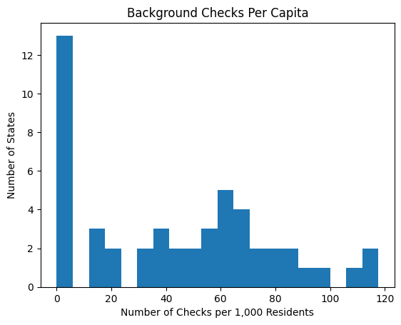

```python
checks_per_capita = df_merged_2016_work['total_checks_per_capita'].plot(kind="hist", bins=20, title="Background Checks Per Capita")
checks_per_capita.set_xlabel("Number of Checks per 1,000 Residents")
checks_per_capita.set_ylabel("Number of States")
```

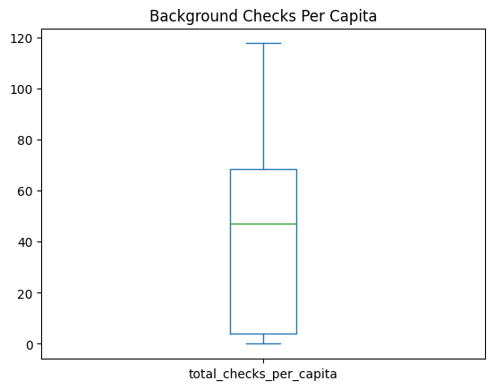

```python
df_merged_2016_work['total_checks_per_capita'].plot(kind="box", title="Background Checks Per Capita")
```

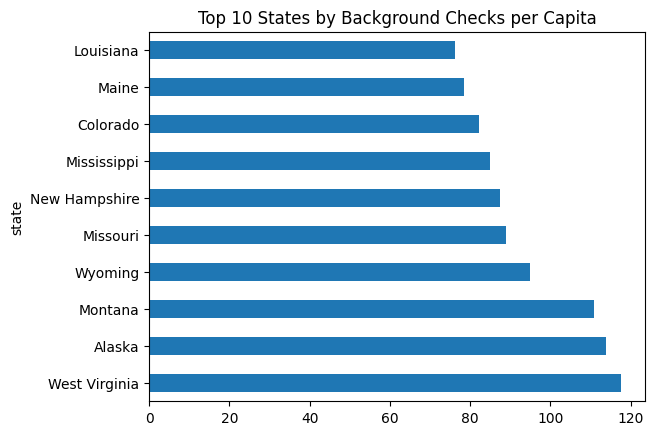

```python
max_check_states = df_merged_2016_work['total_checks_per_capita'].nlargest(10)
max_check_states.plot(kind='barh', title="Top 10 States by Background Checks per Capita")
```

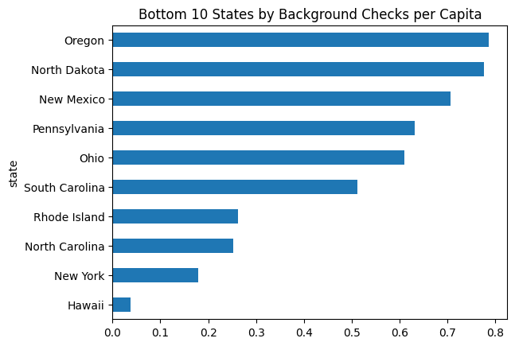

```python
low_check_states = df_merged_2016_work['total_checks_per_capita'].nsmallest(10)
low_check_states.plot(kind='barh', title="Bottom 10 States by Background Checks per Capita")
```

#### Dependent Variable Analysis

In reviewing the initial distributions for the number of firearms background checks per capita, our dependent variable, the statistical details, histogram and box plots reveal the number of tax checks skews heavily towards the low end. This shows that most states most states perform, on average, 44 background checks per 1,000 residents for gun transaction. This is below the median of 47 checks, which is close so not extrely skewed in the middle. While multiple states such as New York showed less than 1 check per 1,000, West Virginia and Alaska perform between 100 and 120. A standard deviation of around 35 implies the highest states do a majority of the 'heavy lifting' for firearms background checks. This creates an interesting data point for review later when comparing to population density and the other factors of gender and race.

#### Independent Variable 1: Population Density

```python
# Review the initial distribution of populations across the states
df_merged_2016_work['population_density_2016'].describe()
```

```
count      50.000000
mean      200.979545
std       266.069896
min         1.300106
25%        45.741897
50%       106.679929
75%       220.071813
max      1216.236256
Name: population_density_2016, dtype: float64
```

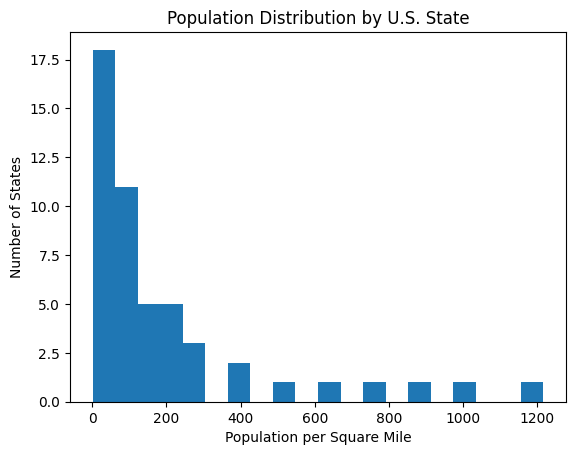

```python
pop_hist = df_merged_2016_work['population_density_2016'].plot(kind='hist', bins=20, title="Population Distribution by U.S. State")
pop_hist.set_xlabel("Population per Square Mile")
pop_hist.set_ylabel("Number of States")
```

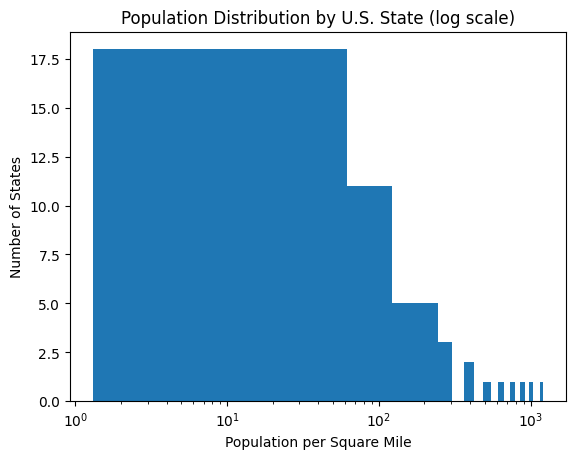

```python
# Log scale of the histogram to show the clear visualization between the low end states and the outlier states on the right side
pop_hist = df_merged_2016_work['population_density_2016'].plot(kind='hist', bins=20, title="Population Distribution by U.S. State (log scale)")
pop_hist.set_xscale('log')
pop_hist.set_xlabel("Population per Square Mile")
pop_hist.set_ylabel("Number of States")
```

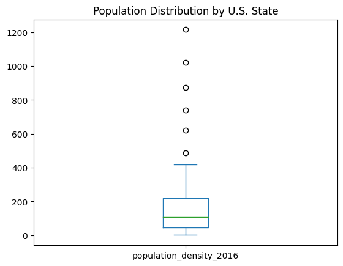

```python
df_merged_2016_work['population_density_2016'].plot(kind="box", title="Population Distribution by U.S. State")
```

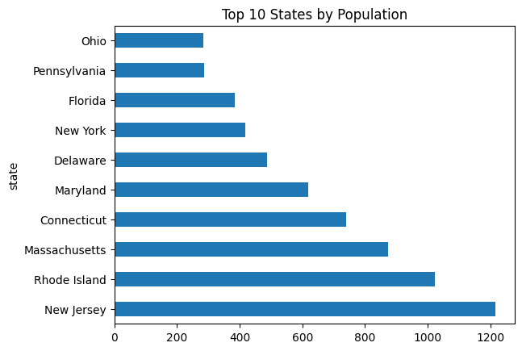

```python
max_pop_states = df_merged_2016_work['population_density_2016'].nlargest(10)
max_pop_states.plot(kind='barh', title="Top 10 States by Population")
```

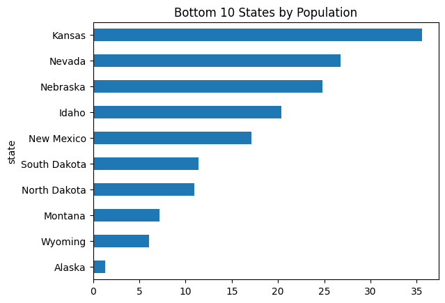

```python
low_pop_states = df_merged_2016_work['population_density_2016'].nsmallest(10)
low_pop_states.plot(kind='barh', title="Bottom 10 States by Population")
```

#### Population Density Analysis

The population density for the U.S. was highly right-skewed in 2016. With a median of 106, and an average of 200 residents per square mile, most states are a bit more sparse in space for residents but a few outliers (New Jersey and Rhode Island for example) are over 1,000 residents per square mile. These urban centers are highlighted on both the histogram (placed into a log scale for clear visibility of the tail difference) and box plots showing the extremes on the tail end of the U.S. population diversity. When comparing the density to the background checks, most states are below 200 residents per square mile (indicated by both the median and mean values) and we can now be aware of the outliers and their potential influence on results.

#### Independent Variable 2: Gender Distributions

```python
# Review the initial distribution of genders across the states
print(" -- FEMALE DISTRIBUTION IN PERCENTAGE --")
print(df_merged_2016_work['female_percent_2016'].describe())

print("\n","-- MALE DISTRIBUTION IN PERCENTAGE --")
print(df_merged_2016_work['male_percent_2016'].describe())
```

```
 -- FEMALE DISTRIBUTION IN PERCENTAGE --
count    50.000000
mean      0.505640
std       0.008012
min       0.477000
25%       0.502000
50%       0.506500
75%       0.511750
max       0.516000
Name: female_percent_2016, dtype: float64

 -- MALE DISTRIBUTION IN PERCENTAGE --
count    50.000000
mean      0.494360
std       0.008012
min       0.484000
25%       0.488250
50%       0.493500
75%       0.498000
max       0.523000
Name: male_percent_2016, dtype: float64
```

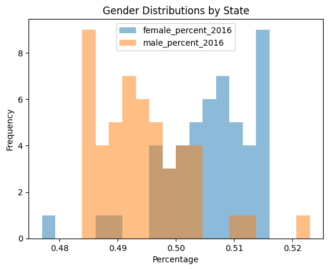

```python
# Overlayed histogram to highlight the comparisons between the genders amongst the states
gen_plot = df_merged_2016_work[['female_percent_2016', 'male_percent_2016']].plot(kind='hist', bins=20, alpha=.5, title="Gender Distributions by State")
gen_plot.set_xlabel("Percentage")
```

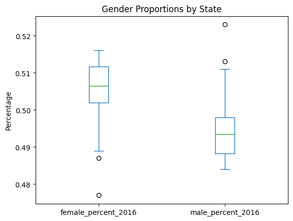

```python
# Side-by-side box plots to highlight the consistency of the gender percentages and mirroring
gen_box = df_merged_2016_work[['female_percent_2016', 'male_percent_2016']].plot(kind='box', title="Gender Proportions by State")
gen_box.set_ylabel("Percentage")
```

#### Independent Variable 3: Racial Composition

```python
race_cols = [
    'white_percent_2016',
    'black_percent_2016',
    'ai_an_percent_2016',
    'asian_percent_2016',
    'pi_percent_2016',
    'two_or_more_percent_2016',
]

df_merged_2016_work[race_cols].describe()
```

|  | white_percent_2016 | black_percent_2016 | ai_an_percent_2016 | asian_percent_2016 | pi_percent_2016 | two_or_more_percent_2016 |
| --- | --- | --- | --- | --- | --- | --- |
| count | 50.000000 | 50.000000 | 50.000000 | 50.00000 | 50.000000 | 50.000000 |
| mean | 0.793080 | 0.110240 | 0.019980 | 0.04342 | 0.003960 | 0.029440 |
| std | 0.123359 | 0.096319 | 0.030651 | 0.05562 | 0.014377 | 0.031868 |
| min | 0.258000 | 0.006000 | 0.002000 | 0.00800 | 0.000000 | 0.012000 |
| 25% | 0.724750 | 0.036250 | 0.005000 | 0.01725 | 0.001000 | 0.019000 |
| 50% | 0.821000 | 0.082000 | 0.007500 | 0.02850 | 0.001000 | 0.022000 |
| 75% | 0.875000 | 0.155250 | 0.016000 | 0.04775 | 0.002000 | 0.027000 |
| max | 0.948000 | 0.377000 | 0.152000 | 0.37700 | 0.102000 | 0.237000 |

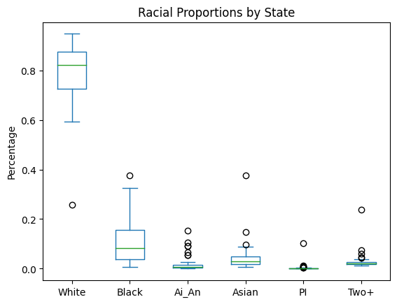

```python
renamed_race = [
    "White",
    "Black",
    "Ai_An",
    "Asian",
    "PI",
    "Two+",
]

df_plot_race = df_merged_2016_work[race_cols].copy()
df_plot_race.columns = renamed_race

race_box = df_plot_race.plot(kind='box', title="Racial Proportions by State")
race_box.set_ylabel("Percentage")
```

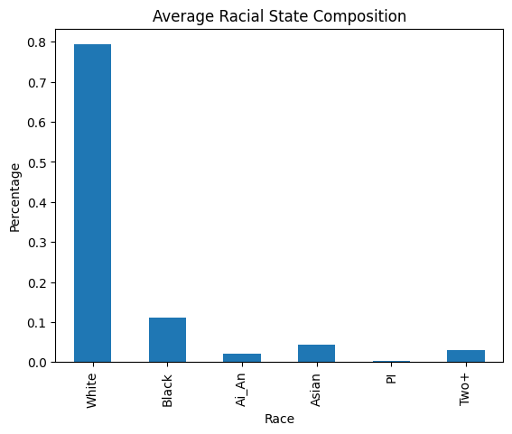

```python
race_bar = df_plot_race.mean().plot(kind='bar', title='Average Racial State Composition')
race_bar.set_xlabel('Race')
race_bar.set_ylabel('Percentage')
```

#### Racial Composition Analysis

The boxplot highlights this variability and shows that White populations have the clear highest percentages well above any other group but also have one of the largest spreads with their outliers. Most other groups are slightly above zero with occasional higher outliers. These racial composition proportions give a good contrast for analysis when we examine whether the proporitions of specific groups provide any differences in firearm background check activity.

### Research Question 1: What is the relationship between population density and firearm background check rates throughout the U.S. in 2016?

```
** Pearson Correlation **:  -0.32738324286917747
** Spearman Correlation **:  -0.3526050420168067
```

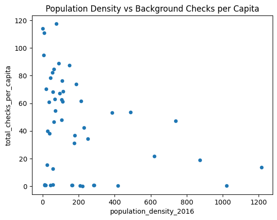

```python
# Density population scatterplot and correlation check
print("** Pearson Correlation **: ", df_merged_2016_work[['population_density_2016', 'total_checks_per_capita']].corr(method='pearson').iloc[0, 1])
print("** Spearman Correlation **: ", df_merged_2016_work[['population_density_2016', 'total_checks_per_capita']].corr(method='spearman').iloc[0, 1])

df_merged_2016_work.plot.scatter(x='population_density_2016', y='total_checks_per_capita', title="Population Density vs Background Checks per Capita")
```

#### Question 1 Analysis: Population Density

The correlation between population density and per capita background checks was calcluated with both Pearson correlation, to determine if there was a linear correlation (approximately -.3274), as well as Spearman to ensure any of the outliers/skewness was accounted for (approximately -.3526).

The correlation between population density and background checks per capita was approximately –0.33 to 0.34 with both correlation methods taken into account. This suggest a weak negative correlation. The scatterplot shows that very densly populated states such as New Jersey and Rhode Island have relatively low check rates, while less densly populated states provided a wide range of values.

### Research Question 2: What is the relationship between gender and firearm background check rates throughout the U.S. in 2016?

```
** Pearson Correlation **:  -0.2737013636514241
** Spearman Correlation **:  -0.22301874953872067
```

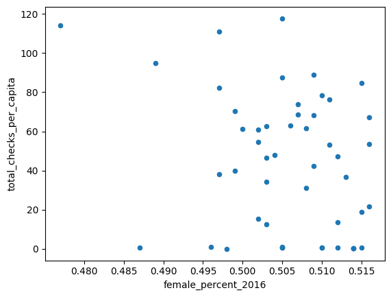

```python
print("** Pearson Correlation **: ", df_merged_2016_work[['female_percent_2016', 'total_checks_per_capita']].corr(method='pearson').iloc[0, 1])
print("** Spearman Correlation **: ", df_merged_2016_work[['female_percent_2016', 'total_checks_per_capita']].corr(method='spearman').iloc[0, 1])

df_merged_2016_work.plot.scatter(x='female_percent_2016', y='total_checks_per_capita')
```

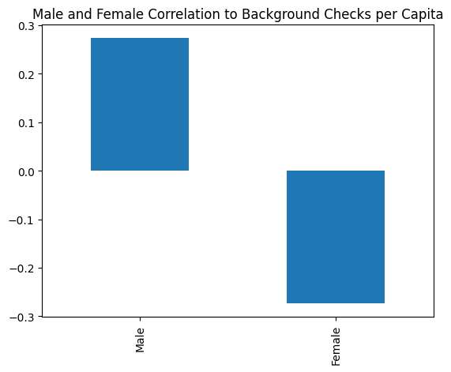

```python
# Bar graph to compare the generders but a mirror effect would be assumed
gender_corrs = {
    'Male': df_merged_2016_work[['male_percent_2016', 'total_checks_per_capita']].corr(method='pearson').iloc[0, 1],
    'Female': df_merged_2016_work[['female_percent_2016', 'total_checks_per_capita']].corr(method='pearson').iloc[0, 1]
}

gender_corrs_df = pd.Series(gender_corrs)

gender_corrs_df.plot(kind="bar", title="Male and Female Correlation to Background Checks per Capita")
```

#### Question 2 Analysis: Gender Composition

Gender composition found little to no relationship with background check rates, regardless of male or female state makeup. The female population varied only slightly between ~48% and ~51% across the states, with a Pearson correlation of –0.2737 and a Spearman correlation of –0.2230 when looked at per-capita. Males, being almost equal in exact number as previously seen, is a mirror effect to females but with opposite correlation signage.

The scatterplot confirms there is little to no trend: states are scattered with no real pattern. The bar chart compares male and female correlations to further show the symmetry.

### Research Question 3: What is the relationship between race and firearm background check rates throughout the U.S. in 2016?

#### White Population Analysis

```
** Pearson Correlation ** : 0.2363972518007559
** Spearman Correlation ** : 0.2985088969734719
```

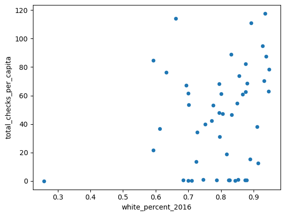

```python
print("** Pearson Correlation ** :", df_merged_2016_work[['white_percent_2016', 'total_checks_per_capita']].corr(method='pearson').iloc[0, 1])
print("** Spearman Correlation ** :", df_merged_2016_work[['white_percent_2016', 'total_checks_per_capita']].corr(method='spearman').iloc[0, 1])

df_merged_2016_work.plot.scatter(x='white_percent_2016', y='total_checks_per_capita')
```

#### Black Population Analysis

```
** Pearson Correlation ** : -0.08671469883116795
** Spearman Correlation ** : -0.19042816588707343
```

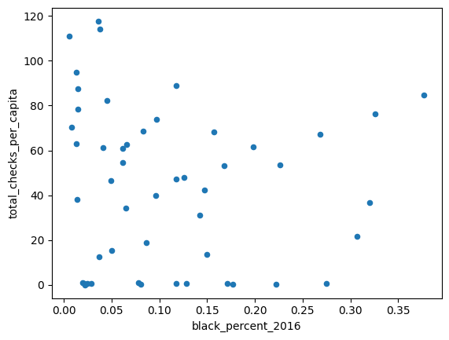

```python
print("** Pearson Correlation ** :", df_merged_2016_work[['black_percent_2016', 'total_checks_per_capita']].corr(method='pearson').iloc[0, 1])
print("** Spearman Correlation ** :", df_merged_2016_work[['black_percent_2016', 'total_checks_per_capita']].corr(method='spearman').iloc[0, 1])

df_merged_2016_work.plot.scatter(x='black_percent_2016', y='total_checks_per_capita')
```

#### American Indian / Alaska Native Analysis

```
** Pearson Correlation ** : 0.02076524537822916
** Spearman Correlation ** : -0.006889945233338427
```

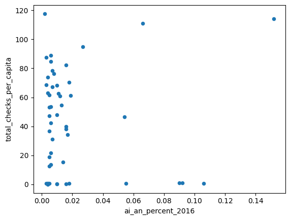

```python
print("** Pearson Correlation ** :", df_merged_2016_work[['ai_an_percent_2016', 'total_checks_per_capita']].corr(method='pearson').iloc[0, 1])
print("** Spearman Correlation ** :", df_merged_2016_work[['ai_an_percent_2016', 'total_checks_per_capita']].corr(method='spearman').iloc[0, 1])

df_merged_2016_work.plot.scatter(x='ai_an_percent_2016', y='total_checks_per_capita')
```

#### Asian Population Analysis

```
** Pearson Correlation ** : -0.25439128585190063
** Spearman Correlation ** : -0.3655584030475146
```

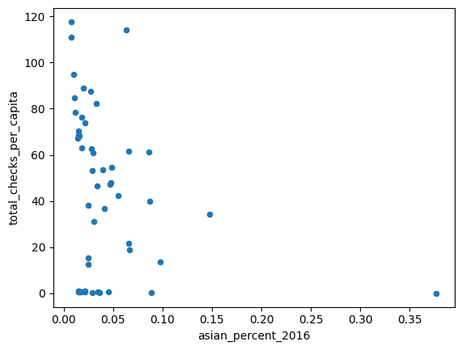

```python
print("** Pearson Correlation ** :", df_merged_2016_work[['asian_percent_2016', 'total_checks_per_capita']].corr(method='pearson').iloc[0, 1])
print("** Spearman Correlation ** :", df_merged_2016_work[['asian_percent_2016', 'total_checks_per_capita']].corr(method='spearman').iloc[0, 1])

df_merged_2016_work.plot.scatter(x='asian_percent_2016', y='total_checks_per_capita')
```

#### Pacific Islander Population Analysis

```
** Pearson Correlation ** : -0.1567306193054732
** Spearman Correlation ** : -0.166969099516857
```

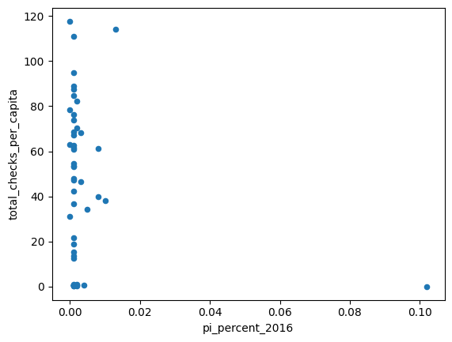

```python
print("** Pearson Correlation ** :", df_merged_2016_work[['pi_percent_2016', 'total_checks_per_capita']].corr(method='pearson').iloc[0, 1])
print("** Spearman Correlation ** :", df_merged_2016_work[['pi_percent_2016', 'total_checks_per_capita']].corr(method='spearman').iloc[0, 1])

df_merged_2016_work.plot.scatter(x='pi_percent_2016', y='total_checks_per_capita')
```

#### Two or More Races Population Analysis

```
** Pearson Correlation ** : -0.1653710865134163
** Spearman Correlation ** : -0.2335531980196685
```

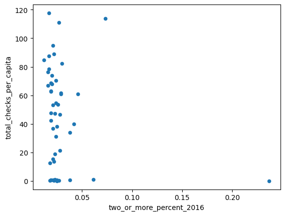

```python
print("** Pearson Correlation ** :", df_merged_2016_work[['two_or_more_percent_2016', 'total_checks_per_capita']].corr(method='pearson').iloc[0, 1])
print("** Spearman Correlation ** :", df_merged_2016_work[['two_or_more_percent_2016', 'total_checks_per_capita']].corr(method='spearman').iloc[0, 1])

df_merged_2016_work.plot.scatter(x='two_or_more_percent_2016', y='total_checks_per_capita')
```

#### Overall Race Analysis Comparison

[figure not shown]

```python
# Combination bar graph created to compare all races together after reviewing them separately
race_corrs = {
    'White': df_merged_2016_work[['black_percent_2016', 'total_checks_per_capita']].corr(method='pearson').iloc[0, 1],
    'Black': df_merged_2016_work[['black_percent_2016', 'total_checks_per_capita']].corr(method='pearson').iloc[0, 1],
    'Ai_An': df_merged_2016_work[['ai_an_percent_2016', 'total_checks_per_capita']].corr(method='pearson').iloc[0, 1],
    'Asian': df_merged_2016_work[['asian_percent_2016', 'total_checks_per_capita']].corr(method='pearson').iloc[0, 1],
    'PI': df_merged_2016_work[['pi_percent_2016', 'total_checks_per_capita']].corr(method='pearson').iloc[0, 1],
    'Two+': df_merged_2016_work[['two_or_more_percent_2016', 'total_checks_per_capita']].corr(method='pearson').iloc[0, 1]
}

race_corrs_df = pd.Series(race_corrs)

race_corrs_df.plot(kind="bar", title="Correlations of Racial Compositions to Background Checks per Capita")
```

#### Question 3 Analysis: Racial Composition

The final analsys of the Correlations between racial composition and firearm background check rates were fairly weak to very weak across the board. Scatter plots were created for each race and only one, the Asian population, showed a potentially weak correlation when values are taken non-linearly with a Spearman correlation. But, linearly, there is no signficant correlation found. All the races are similar in showing no definitive patterns throughout the racial compositions for each state.

## Conclusions

[figure not shown]

```python
total_corrs = {
    'Pop_density': df_merged_2016_work[['population_density_2016', 'total_checks_per_capita']].corr(method='pearson').iloc[0, 1],
    'Female': df_merged_2016_work[['male_percent_2016', 'total_checks_per_capita']].corr(method='pearson').iloc[0, 1],
    'Male': df_merged_2016_work[['female_percent_2016', 'total_checks_per_capita']].corr(method='pearson').iloc[0, 1],
    'White': df_merged_2016_work[['black_percent_2016', 'total_checks_per_capita']].corr(method='pearson').iloc[0, 1],
    'Black': df_merged_2016_work[['black_percent_2016', 'total_checks_per_capita']].corr(method='pearson').iloc[0, 1],
    'Ai_An': df_merged_2016_work[['ai_an_percent_2016', 'total_checks_per_capita']].corr(method='pearson').iloc[0, 1],
    'Asian': df_merged_2016_work[['asian_percent_2016', 'total_checks_per_capita']].corr(method='pearson').iloc[0, 1],
    'PI': df_merged_2016_work[['pi_percent_2016', 'total_checks_per_capita']].corr(method='pearson').iloc[0, 1],
    'Two+': df_merged_2016_work[['two_or_more_percent_2016', 'total_checks_per_capita']].corr(method='pearson').iloc[0, 1]
}

total_corrs_df = pd.Series(total_corrs)

total_corrs_df.plot(kind='bar', title='2016 State Demographic Correlations against Firearm Background Checks per Capita')
```

This analysis project investigated the relationship between multiple demographic factors (population density, gender, and race) against FBI firearm background check rates across all U.S. states in 2016.

Gender composition was nearly identical across states (almost 50% for both males and females). Results showed no meaningful relationship when viewed against firearm background check activity (approximately –0.27 for females and near identical for males in the positive direction). In summary, gender proportions do not explain or provide much information on differences in background check activity across states.

Overall, the results indicate that state-level demographic compositions and populations do not strongly predict firearm background check activity. Outlier states like West Virginia (high amount of checks but lower population density) and New York (low amount of checks with higher population density) highlight that policy, culture and other regulatory factors play a larger role than demographics on their own in terms of states completing required firearm transaction background checks.

In terms of hypotheses stated in the intro:

The final correlation summary bar chart, shown directly above, provides the final results all demographic factors had correlations close to or near near zero, with no variable reaching +/- 0.4.

### Limitation Analysis

This project analysis has multiple limitations that must be acknowledged.

1. In terms of demographics information, or at least the demographics covered in this particular analysis, the dataset is limited to 2016. While there are a few other time periods mentioned for other categories, they are also specific to certain years and snapshots in time. Because of the limited information available for a single year, we cannot capture changes in demographic or firearm background checks over time.
2. The NICS dataset only records firearm **background checks** and not firearm **purchases**. That means the counts may not directly reflect sales behavior which would haved allowed a much more thorough analysis of actual social impacts brought about by differences in race and gender.
3. The Census data had inconsistencies and errors in multiple pieces of data (e.g., some states reported proportional data instead of percentages which mixed data and required custom functions). There were also a few states with missing values for an entire racial category (Pacific Islanders), which required cleaning and imputation which could affect overall precision.
4. Lastly, because the analysis is based on state-level data, there could be differences and effects happening with demographics from *within-state* differences. We are unable to interpret these causal relationships.

These limitations more clearly identify that this analysis provides useful insights into potential correlations between demographics and firearms background checks, but further research with cleaner and more drilled-down data would provide stronger conclusions.